# DOPPIO model data

This one is a little bit complicated, but we can make some rough plots.

As usual, the data is available on a thredds server:

http://tds.marine.rutgers.edu/thredds/dodsC/roms/doppio/2017_da/avg/Averages_Best

```python
import xarray as xr
import matplotlib.pyplot as plt

%matplotlib inline
```

# read in the data

available at:

```
url = 'http://tds.marine.rutgers.edu/thredds/dodsC/roms/doppio/2017_da/avg/Averages_Best'
```

```python
url = 'http://tds.marine.rutgers.edu/thredds/dodsC/roms/doppio/2017_da/avg/Averages_Best'

ds = xr.open_dataset(url)

ds
```

```
<xarray.Dataset>
Dimensions:         (s_rho: 40, s_w: 41, eta_rho: 106, xi_rho: 242, eta_u: 106, xi_u: 241, eta_v: 105, xi_v: 242, eta_psi: 105, xi_psi: 241, ocean_time: 1, time: 1393, tracer: 2, boundary: 4)
Coordinates: (12/13)
  * s_rho           (s_rho) float64 -0.9875 -0.9625 -0.9375 ... -0.0375 -0.0125
  * s_w             (s_w) float64 -1.0 -0.975 -0.95 -0.925 ... -0.05 -0.025 0.0
    lon_rho         (eta_rho, xi_rho) float64 -75.19 -75.13 ... -64.62 -64.54
    lat_rho         (eta_rho, xi_rho) float64 32.24 32.28 32.32 ... 46.58 46.61
    lon_u           (eta_u, xi_u) float64 -75.16 -75.1 -75.05 ... -64.66 -64.58
    lat_u           (eta_u, xi_u) float64 32.26 32.3 32.34 ... 46.53 46.56 46.59
    ...              ...
    lat_v           (eta_v, xi_v) float64 32.26 32.3 32.34 ... 46.52 46.55 46.59
    lon_psi         (eta_psi, xi_psi) float64 -75.19 -75.13 ... -64.63 -64.56
    lat_psi         (eta_psi, xi_psi) float64 32.28 32.32 32.36 ... 46.53 46.57
  * ocean_time      (ocean_time) datetime64[ns] 2021-07-28T12:00:00
  * time            (time) datetime64[ns] 2017-11-02T12:00:00 ... 2021-08-25T...
    time_run        (time) datetime64[ns] 2017-11-01T12:00:00 ... 2021-08-20T...
Dimensions without coordinates: eta_rho, xi_rho, eta_u, xi_u, eta_v, xi_v, eta_psi, xi_psi, tracer, boundary
Data variables: (12/108)
    ntimes          int32 720
    ndtfast         int32 30
    dt              float64 360.0
    dtfast          float64 12.0
    dstart          datetime64[ns] 2021-07-28
    shuffle         int32 1
    ...              ...
    shflux          (time, eta_rho, xi_rho) float64 ...
    ssflux          (time, eta_rho, xi_rho) float64 ...
    swrad_daily     (time, eta_rho, xi_rho) float64 ...
    sustr           (time, eta_u, xi_u) float64 ...
    svstr           (time, eta_v, xi_v) float64 ...
    time_offset     (time) datetime64[ns] 2017-11-02 2017-11-02 ... 2017-11-06
Attributes: (12/46)
    file:                            doppio_avg_5687_0001.nc
    format:                          netCDF-4/HDF5 file
    Conventions:                     CF-1.4, SGRID-0.3
    type:                            ROMS/TOMS nonlinear model averages file
    title:                           ROMS doppio Real-Time Operational PSAS F...
    var_info:                        ../Data/varinfo1040t_daily.dat
    ...                              ...
    frc_file_07:                     ../Data/Winds_ncepnam_3hourly_MAB_and_Go...
    cdm_data_type:                   GRID
    featureType:                     GRID
    location:                        Proto fmrc:doppio_2017_da_avg
    summary:                         doppio
    DODS_EXTRA.Unlimited_Dimension:  ocean_time
```

# WHOA crazy stuff.

Models are crazy, they are solved and represented on complex grids with strange names.

Let's not worry about the details here, but we can still make some plots.

This data is very big, so we need to make sure we take a subset.

The other `.sel()` I want to do is to take `s_rho=0, method='nearest'` which takes the "surface" level of the model so we can plot it. Don't worry about these details too much, I just want to show you that we can access even really complicated operational model data with our fairly simple tools.

fill in the blanks:

```
subset = ds.___( ___ = '2021-08-21', s_rho =0, ___ = 'nearest')

subset
```

```python
subset = ds.sel(time = '2021-08-21', s_rho =0, method = 'nearest')
subset
```

```
<xarray.Dataset>
Dimensions:         (s_w: 41, eta_rho: 106, xi_rho: 242, eta_u: 106, xi_u: 241, eta_v: 105, xi_v: 242, eta_psi: 105, xi_psi: 241, ocean_time: 1, time: 1, tracer: 2, boundary: 4)
Coordinates: (12/13)
    s_rho           float64 -0.0125
  * s_w             (s_w) float64 -1.0 -0.975 -0.95 -0.925 ... -0.05 -0.025 0.0
    lon_rho         (eta_rho, xi_rho) float64 -75.19 -75.13 ... -64.62 -64.54
    lat_rho         (eta_rho, xi_rho) float64 32.24 32.28 32.32 ... 46.58 46.61
    lon_u           (eta_u, xi_u) float64 -75.16 -75.1 -75.05 ... -64.66 -64.58
    lat_u           (eta_u, xi_u) float64 32.26 32.3 32.34 ... 46.53 46.56 46.59
    ...              ...
    lat_v           (eta_v, xi_v) float64 32.26 32.3 32.34 ... 46.52 46.55 46.59
    lon_psi         (eta_psi, xi_psi) float64 -75.19 -75.13 ... -64.63 -64.56
    lat_psi         (eta_psi, xi_psi) float64 32.28 32.32 32.36 ... 46.53 46.57
  * ocean_time      (ocean_time) datetime64[ns] 2021-07-28T12:00:00
  * time            (time) datetime64[ns] 2021-08-21T12:00:00
    time_run        (time) datetime64[ns] 2021-08-20T12:00:00
Dimensions without coordinates: eta_rho, xi_rho, eta_u, xi_u, eta_v, xi_v, eta_psi, xi_psi, tracer, boundary
Data variables: (12/108)
    ntimes          int32 720
    ndtfast         int32 30
    dt              float64 360.0
    dtfast          float64 12.0
    dstart          datetime64[ns] 2021-07-28
    shuffle         int32 1
    ...              ...
    shflux          (time, eta_rho, xi_rho) float64 -226.8 -219.4 ... nan nan
    ssflux          (time, eta_rho, xi_rho) float64 -1.727e-06 ... nan
    swrad_daily     (time, eta_rho, xi_rho) float64 83.64 88.59 ... nan nan
    sustr           (time, eta_u, xi_u) float64 0.09112 0.09174 ... nan nan
    svstr           (time, eta_v, xi_v) float64 -0.08657 -0.08407 ... nan nan
    time_offset     (time) datetime64[ns] 2017-11-02
Attributes: (12/46)
    file:                            doppio_avg_5687_0001.nc
    format:                          netCDF-4/HDF5 file
    Conventions:                     CF-1.4, SGRID-0.3
    type:                            ROMS/TOMS nonlinear model averages file
    title:                           ROMS doppio Real-Time Operational PSAS F...
    var_info:                        ../Data/varinfo1040t_daily.dat
    ...                              ...
    frc_file_07:                     ../Data/Winds_ncepnam_3hourly_MAB_and_Go...
    cdm_data_type:                   GRID
    featureType:                     GRID
    location:                        Proto fmrc:doppio_2017_da_avg
    summary:                         doppio
    DODS_EXTRA.Unlimited_Dimension:  ocean_time
```

# plot the model salinity

let's plot the models salinity using the built-in xarray plotting. In this case I want to explicitly tell xarrays's `.plot()` that I want the x and y axes of the plot to be `lon_rho` and `lat_rho`, which we do by adding a `x=` and `y=` argument in `.plot()`. I also want to set the color limits of the plot, which we can do with `vmin=__, vmax=__` as more arguments in `.plot()`.

putting it all together our new type of plot code will look like:

```
subset.___.plot( x='lon_rho', y='lat_rho', vmin=28, vmax=35)
```

fill in the blanks to make it plot the salinity

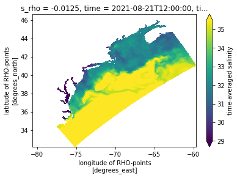

```python
subset.salt.plot( x='lon_rho', y='lat_rho', vmin=29, vmax=35.5)
```

# plot the model temperature

using the plotting code you just filled in, modify it to create a plot of temperature. Be sure to change the `vmin, vmax` limits to a range that makes sense for temperature.

try changing the colormap by adding the argument `cmap = 'RdYlBu_r'` to `.plot()`

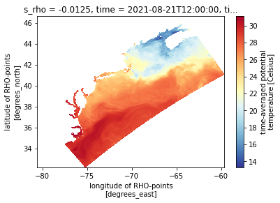

```python
subset.temp.plot( x='lon_rho', y='lat_rho', cmap = 'RdYlBu_r')
```

## Plot change in ocean temperature due to Hurricane Henri

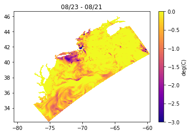

```python
subset = ds.sel(time = '2021-08-21', s_rho =0, method = 'nearest')
subset0 = subset.temp.values
subset1 = ds.sel(time = '2021-08-23', s_rho =0, method = 'nearest')
subset1 = subset1.temp.values

deltaT = subset1 - subset0

plt.pcolormesh(subset.lon_rho , subset.lat_rho,deltaT.squeeze(),shading = 'auto',vmin = -3, vmax = 0,cmap = 'plasma')
cbar = plt.colorbar();
cbar.set_label('deg(C)')
plt.title('08/23 - 08/21')
plt.savefig('henri_cooling.png', format='png',dpi = 600)
```